# Análisis del Nivel Educativo y la Estructura Económica en Viña del Mar

Diego Ñanculef Soto

# 1. Introducción

Las ciudades son espacios donde se expresan, con especial nitidez, las desigualdades sociales y económicas. Lejos de ser escenarios homogéneos, los territorios urbanos reflejan profundas asimetrías en el acceso a oportunidades, recursos y condiciones de vida digna. Estas desigualdades no son casuales, sino que obedecen a procesos históricos de planificación y desarrollo que han privilegiado ciertos sectores sociales en desmedro de otros.

Viña del Mar, reconocida por su atractivo turístico y su dinamismo económico, también presenta contrastes significativos en su estructura interna. Mientras algunas zonas concentran altos niveles de bienestar y acceso a servicios, otras evidencian rezagos persistentes en materia educativa, laboral y habitacional. En este escenario, el nivel educativo y la inserción en el mercado laboral son dimensiones clave para comprender las trayectorias de desarrollo de su población.

La educación, entendida como un pilar fundamental para la movilidad social, no se distribuye de forma equitativa entre los distintos sectores de la ciudad. Asimismo, la estructura económica local –caracterizada por altos niveles de empleo informal, baja calificación laboral y segmentación sectorial– condiciona fuertemente las oportunidades de progreso, especialmente para los grupos más vulnerables.

A partir de esta problemática, el presente trabajo tiene como objetivo analizar la relación entre el nivel educativo y la estructura económica de la ciudad de Viña del Mar, a través del estudio de datos provenientes del Censo 2017. Se busca identificar patrones territoriales que permitan visibilizar las brechas existentes en materia de formación académica y condiciones laborales, aportando a una comprensión más integral de las dinámicas urbanas y sus implicancias sociales.

Este análisis territorial pretende contribuir con evidencia empírica para el diseño de políticas públicas orientadas a reducir la desigualdad urbana y fomentar un desarrollo más justo, equitativo y sostenible en el contexto local.

## 1.1. Objetivo General

El objetivo general de este trabajo es analizar la distribución territorial del nivel educativo de la población y su relación con la estructura económica local en la ciudad de Viña del Mar, con el fin de identificar brechas socioeconómicas a nivel intraurbano.

## 1.2. Objetivos Específicos

Los objetivos específicos por trabajar son:

- Construir un índice de nivel educativo que relacione la proporción de personas con educación básica, media y superior en cada zona censal de Viña del Mar.
- Caracterizar la estructura económica local mediante indicadores como la participación laboral, tipo de ocupación y nivel de ingresos.
- Representar espacialmente ambos indicadores (educativo y económico) a nivel de zona censal para visualizar las desigualdades territoriales.

Identificar áreas críticas donde se concentran bajos niveles educativos y condiciones laborales precarias, mediante un análisis bivariado de vulnerabilidad socioeconómica.

# 2. Desarrollo

## 2.1. Metodología

Para el análisis del nivel educativo y la estructura económica de la población urbana de Viña del Mar, se utilizaron datos del Censo 2017, procesados con las herramientas pgAdmin y RStudio. La unidad de análisis fue la zona censal urbana, lo que permitió un mayor nivel de desagregación espacial y la identificación de diferencias intra-comunales.

Se trabajó con las tablas personas, hogares, viviendas, zonas y comunas, complementadas con la tabla variables_codificacion para interpretar adecuadamente los códigos de las variables utilizadas. En cuanto al nivel educativo, se utilizó la variable escolaridad, identificando los códigos que representaban educación media o superior (valores del 7 al 14), y se calculó el porcentaje de personas con este nivel como proporción del total con datos válidos. Este indicador permitió estimar el capital educativo en cada zona.

Para caracterizar la estructura económica, se empleó la variable p18, que clasifica a las personas según su rama de actividad económica. Se calcularon los siguientes indicadores: porcentaje de personas ocupadas (excluyendo códigos 98 y 99), número de personas empleadas en el sector agrícola (código ‘A’), número de personas en otras actividades económicas (códigos ‘B’ a ‘Z’, excluyendo ‘A’), y número de casos no aplicables (98 y 99). Cabe señalar que solo se contó con descripción detallada para el código ‘A’, lo que limitó el análisis de las demás ramas económicas.

Todos los indicadores fueron calculados mediante consultas SQL en pgAdmin, y posteriormente visualizados en RStudio, con el objetivo de identificar zonas críticas de vulnerabilidad social en la comuna. La correcta interpretación de los códigos fue fundamental para garantizar la precisión del análisis.

## 2.1.1. Librerías necesarias

Para desarrollar el análisis en R se cargaron las siguiente librerías:

```r
library(DBI)
library(RPostgres)
library(sf)
library(ggplot2)
library(cowplot)
library(biscale)
```

Estas librerías permiten establecer conexiones con bases de datos PostgreSQL, manejar geometrías espaciales (`sf`) y generar visualizaciones estadísticas y cartográficas.

## 2.1.2. Conexión a la base de datos PostgreSQL

Las variables consideradas son:

- p.escolaridad: Años de escolaridad (nivel educacional)
- p18: Rama de la actividad economica (ocupación)

Para representar espacialmente los indicadores de nivel educativo y estructura económica en Viña del Mar, primero fueron obtenidos mediante una consulta SQL aplicada sobre las zonas urbanas de la comuna, utilizando como unidad de análisis el código de zona censal (geocodigo). El procesamiento y visualización se realizó en RStudio, utilizando las librerías DBI, sf y tidyverse.

A continuación, se describen los indicadores construidos:

- Porcentaje de personas con educación media o superior, calculado a partir del campo p.escolaridad, considerando como nivel medio o superior los valores entre 7 y 14.
- Porcentaje de personas ocupadas, según la variable p.18, considerando ocupación válida todo valor distinto de ‘98’ (no aplica) y ‘99’ (no sabe).
- Número de personas ocupadas en agricultura, correspondiente al valor ‘A’ en p.18.
- Número de personas ocupadas en otras actividades económicas, que incluye los códigos ‘B’ a ‘Z’ en p.18.
- Número de personas con actividad no aplicable o sin información, es decir, con valores ‘98’ o ‘99’ en p.18.

  La consulta SQL generó una tabla con los siguientes campos por zona censal:

  | **Variable** | **Descripción** |
  | --- | --- |
  | geocodigo | Código único de identificación de la zona censal (clave espacial para el análisis territorial). |
  | nom_comuna | Nombre de la comuna, en este caso exclusivamente “Viña del Mar”. |
  | porcentaje_educacion_media_o_mas | Porcentaje de personas en la zona censal que han alcanzado educación media o superior (valores entre 7 y 14 en p.escolaridad). Indica el nivel general de capital educativo. |
  | porcentaje_ocupados | Porcentaje de personas en la zona censal que se encuentran ocupadas, según la variable p.p18 (excluye códigos ‘98’ y ‘99’). Refleja el grado de inserción laboral. |
  | num_agricultura | Número de personas cuya actividad económica corresponde al sector agrícola (código ‘A’ en p.p18). |
  | num_otras_actividades | Número de personas ocupadas en sectores distintos a la agricultura, considerando los códigos ‘B’ a ‘Z’ en p.p18. |
  | num_no_aplicables | Número de personas con códigos ‘98’ o ‘99’ en p.p18, que indican condición no aplicable o sin información. Este valor puede reflejar exclusión del mercado laboral o vacíos censales. |

  Este procedimiento permitió construir un mapa temático con los indicadores seleccionados, visualizando con mayor detalle las disparidades espaciales en materia de educación y estructura económica dentro de Viña del Mar.

Luego se extrajo la geometría correspondiente a las zonas censales de la Comuna de Viña del Mar

Posteriormente, se integran los datos censales previamente procesados con la geometria espacial, generando asi una tabla espacial final lista para su visualización.

## 2.2 Análisis y Resultados

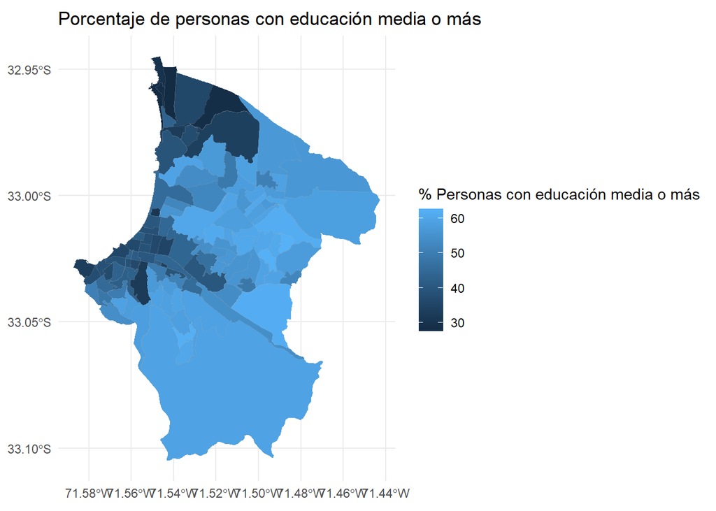

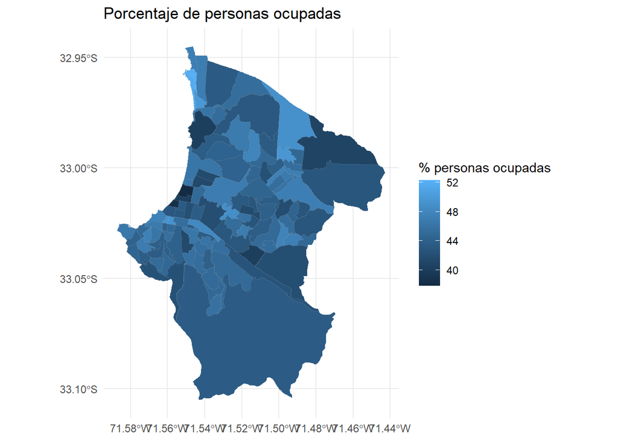

En base a los datos obtenidos, se construye el gráfico de dispersión que representa lo observado en los mapas mostrados en el apartado anterior.

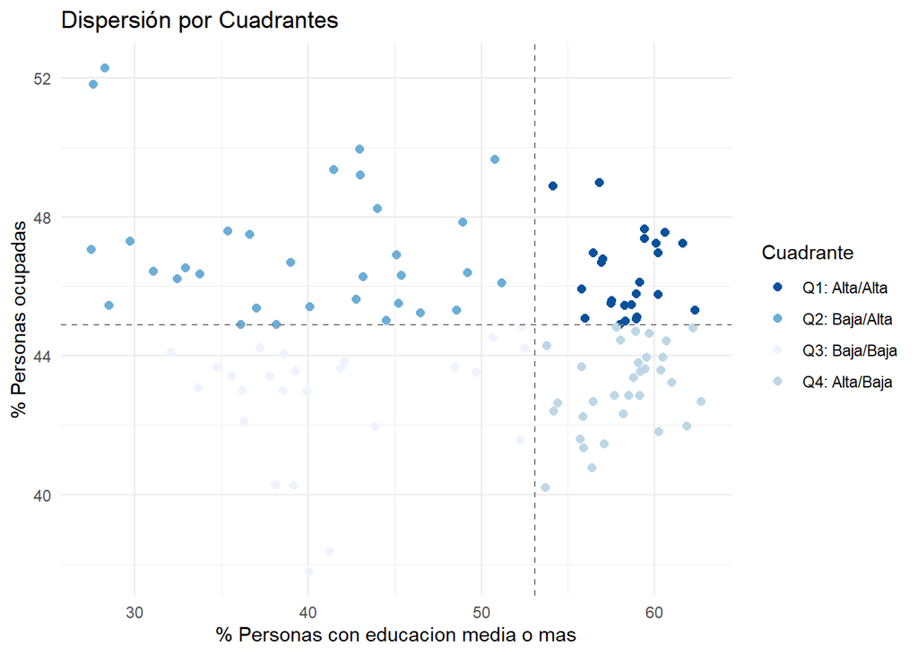

1. Dispersión de Escolaridad por Cuadrante

Interpretación: Zonas con mayor cohesión social tienden a ser más homogéneas en nivel educativo. La dispersión en la periferia indica fragmentación social y educativa en áreas con expansión urbana informal o asentamientos irregulares.

2. Dispersión de Actividad Económica por Cuadrante (Variable P18)

Interpretación: La dispersión económica indica diversidad funcional de los territorios, pero también puede representar falta de especialización o planificación urbana.

Finalmente, se genera un mapa bivariado, el cual sintetiza las variables analizadas en este trabajo.

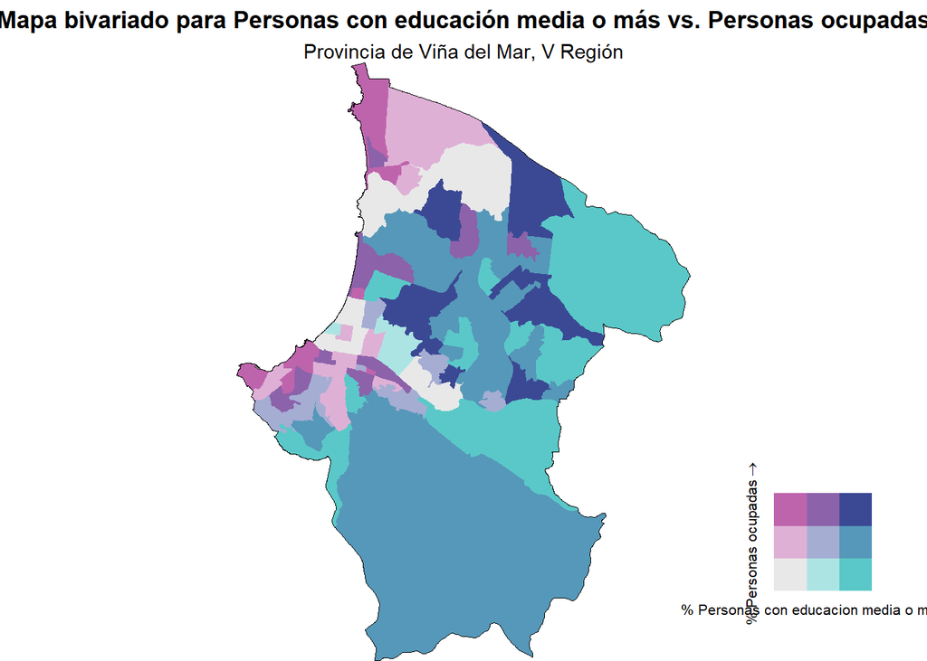

Este tipo de mapa combina dos variables simultáneamente mediante una escala de colores combinados (normalmente, ejes cruzados de color que representan niveles de una variable en una dirección y otra en la perpendicular).

Utilidad del mapa bivariado:

- Facilita la identificación de zonas prioritarias para intervención pública.
- Permite focalizar programas de capacitación laboral, fortalecimiento educativo, o reconversión productiva.

# 3. Conclusión

Este análisis de Viña del Mar, utilizando datos censales de 2017 y herramientas como pgAdmin, SQL y RStudio, revela patrones territoriales de desigualdad en el acceso a educación y empleo. Aunque la variable de escolaridad proporcionó una base de información sólida, el estudio de la estructura económica se vio limitado por la escasez y falta de documentación de datos detallados.

La dispersión espacial subraya una ciudad estructurada en ejes de desigualdad, con marcadas diferencias entre el norte costero y el sur interior. Estas brechas no solo reflejan desigualdades materiales, sino también en el acceso a trayectorias de vida digna.

El mapa bivariado es una herramienta clave para la toma de decisiones, ya que permite focalizar intervenciones en áreas con bajos niveles educativos y exclusión laboral. Sin embargo, el estudio también destacó la necesidad urgente de mejorar la recolección y codificación de datos económicos, especialmente la desagregación de ramas de actividad, para obtener diagnósticos precisos.

En síntesis, este trabajo ofrece un diagnóstico técnico sobre las desigualdades intraurbanas en Viña del Mar y una base metodológica replicable. Es un llamado a fortalecer los instrumentos de observación territorial para avanzar hacia una ciudad más justa, equitativa y sostenible, partiendo del reconocimiento de estas brechas y actuando en consecuencia.

# 4. Bibliografia

- Centro de Estudios MINEDUC. (2022). *Evidencias N°55: Factores asociados a la deserción escolar en jóvenes chilenos*. Ministerio de Educación de Chile. Recuperado de https://centroestudios.mineduc.cl/wp-content/uploads/sites/100/2022/11/EVIDENCIAS-55_2022_fd01.pdf
- Figueroa, E. (2015). Desigualdad en Chile: La continua relevancia de la clase social. RIL Editores.
- Sabatini, F., Wormald, G., Sierralta, C., & Peters, P. (2010). Segregación residencial en las principales ciudades chilenas: Tendencias de las tres últimas décadas y posibles cursos de acción. Programa de Naciones Unidas para el Desarrollo (PNUD).
- Valenzuela, J. P. (2016). Desigualdad de oportunidades educativas en Chile: Situación actual, desafíos y propuestas de política pública. Universidad de Chile - Centro de Estudios de Políticas y Prácticas en Educación (CEPPE).
- Instituto Nacional de Estadísticas (INE). (2017). *Censo de Población y Vivienda 2017*. Recuperado de https://www.censo2017.cl